# simon-5505-04-slides

## Topics to be covered

- What you will learn
  - Review statistics for continuous outcomes
  - Counts, proportions, and percentages
  - Crosstabulations
  - Bar plots
  - New categorical variables

## The Titanic dataset, 1

The Titanic was a large cruise ship, the biggest of its kind in 1912. It was thought to be unsinkable, but when it set sail from England to America in its maiden voyage, it struck an iceberg and sank, killing many of the passengers and crew. You can get fairly good data on the characteristics of passengers who died and compare them to those that survived. The data indicate a strong effect due to age and gender, representing a philosophy of “women and children first” that held during the boarding of life boats.

## The Titanic dataset, 2

```
Rows: 1,313
Columns: 5
$ name     <chr> "Allen, Miss Elisabeth Walton", "Allison, Miss Helen Loraine"…
$ pclass   <chr> "1st", "1st", "1st", "1st", "1st", "1st", "1st", "1st", "1st"…
$ age      <dbl> 29.00, 2.00, 30.00, 25.00, 0.92, 47.00, 63.00, 39.00, 58.00, …
$ sex      <chr> "female", "female", "male", "female", "male", "male", "female…
$ survived <dbl> 1, 0, 0, 0, 1, 1, 1, 0, 1, 0, 0, 1, 1, 1, 0, 1, 0, 0, 1, 1, 1…
```

## Peek at the bottom

[output not shown]

## Descriptive statistics on age

[output not shown]

## Print out information on youngest and oldest passengers

[output not shown]

## Break #1

- What you have learned
  - Review statistics for continuous outcomes
- What’s coming next
  - Counts, proportions, and percentages

## Categorical versus continuous variables

- Categorical
  - Small number of possible values
  - Each value has a name or label
- Continuous
  - Large number of possible values
  - Potentially any value in a range.

## A hypothetical dataset

```
# A tibble: 10 × 1
   grp
   <chr>
 1 a
 2 b
 3 b
 4 c
 5 c
 6 c
 7 d
 8 d
 9 d
10 d
```

## Counts and percentages, 1

```r
hypo_1 |>
  count(grp)
```

```
# A tibble: 4 × 2
  grp       n
  <chr> <int>
1 a         1
2 b         2
3 c         3
4 d         4
```

## Counts and percentages, 2

```r
hypo_1 |>
  count(grp) |>
  mutate(total=sum(n)) |>
  mutate(pct=100*n/total)
```

```
# A tibble: 4 × 4
  grp       n total   pct
  <chr> <int> <int> <dbl>
1 a         1    10    10
2 b         2    10    20
3 c         3    10    30
4 d         4    10    40
```

## Counts and percentages, 3

```r
hypo_1 |>
  count(grp) |>
  mutate(total=sum(n)) |>
  mutate(pct=100*n/total) |>
  mutate(pct=glue("{n}/{total} ({round(pct)}%)")) |>
  select(-n, -total)
```

```
# A tibble: 4 × 2
  grp   pct
  <chr> <glue>
1 a     1/10 (10%)
2 b     2/10 (20%)
3 c     3/10 (30%)
4 d     4/10 (40%)
```

## Break #2

- What you have learned
  - Counts, proportions, and percentages
- What’s coming next
  - Crosstabulations

## Hypothetical dataset

```
# A tibble: 10 × 2
   intervention result
   <chr>        <chr>
 1 c            f
 2 c            s
 3 c            s
 4 t            f
 5 t            f
 6 t            f
 7 t            s
 8 t            s
 9 t            s
10 t            s
```

## Counts by intervention and result

```r
hypo_2 |>
  count(intervention, result)
```

```
# A tibble: 4 × 3
  intervention result     n
  <chr>        <chr>  <int>
1 c            f          1
2 c            s          2
3 t            f          3
4 t            s          4
```

## Counts by result and intervention

```r
hypo_2 |>
  count(result, intervention)
```

```
# A tibble: 4 × 3
  result intervention     n
  <chr>  <chr>        <int>
1 f      c                1
2 f      t                3
3 s      c                2
4 s      t                4
```

## Rectangular layout, rows are result

```r
hypo_2 |>
  count(intervention, result) |>
  pivot_wider(
    names_from=intervention,
    values_from=n)
```

```
# A tibble: 2 × 3
  result     c     t
  <chr>  <int> <int>
1 f          1     3
2 s          2     4
```

```r
hypo_2 |>
  count(intervention, result) |>
  pivot_wider(
    names_from=result,
    values_from=n)
```

```
# A tibble: 2 × 3
  intervention     f     s
  <chr>        <int> <int>
1 c                1     2
2 t                3     4
```

## Conditional probabilities, 1

```r
hypo_2 |>
  count(intervention, result) |>
    group_by(intervention) |>
    mutate(total=sum(n)) |>
    mutate(pct=round(100*n/total)) -> prob_1

prob_1
```

```
# A tibble: 4 × 5
# Groups:   intervention [2]
  intervention result     n total   pct
  <chr>        <chr>  <int> <int> <dbl>
1 c            f          1     3    33
2 c            s          2     3    67
3 t            f          3     7    43
4 t            s          4     7    57
```

## Conditional probabilities, 2

```r
hypo_2 |>
  count(intervention, result) |>
    group_by(result) |>
    mutate(total=sum(n)) |>
    mutate(pct=round(100*n/total)) -> prob_2

prob_2
```

```
# A tibble: 4 × 5
# Groups:   result [2]
  intervention result     n total   pct
  <chr>        <chr>  <int> <int> <dbl>
1 c            f          1     4    25
2 c            s          2     6    33
3 t            f          3     4    75
4 t            s          4     6    67
```

## Interpretation, 1

```
# A tibble: 4 × 6
# Groups:   intervention [2]
  intervention result     n total   pct interpretation
  <chr>        <chr>  <int> <int> <dbl> <chr>
1 c            f          1     3    33 P[f|c]
2 c            s          2     3    67 P[s|c]
3 t            f          3     7    43 P[f|t]
4 t            s          4     7    57 P[s|t]
```

## Interpretation, 2

```
# A tibble: 4 × 6
# Groups:   result [2]
  intervention result     n total   pct interpretation
  <chr>        <chr>  <int> <int> <dbl> <chr>
1 c            f          1     4    25 P[c|f]
2 c            s          2     6    33 P[c|s]
3 t            f          3     4    75 P[t|f]
4 t            s          4     6    67 P[t|s]
```

## Rectangular arangement of probabilities, 1

```
# A tibble: 2 × 3
# Groups:   intervention [2]
  intervention     f     s
  <chr>        <dbl> <dbl>
1 c               33    67
2 t               43    57
```

## Rectangular arangement of probabilities, 2

```
# A tibble: 2 × 3
  result     c     t
  <chr>  <dbl> <dbl>
1 f         33    43
2 s         67    57
```

## The proximity principle, 1

```
# A tibble: 2 × 3
# Groups:   intervention [2]
  intervention     f     s
  <chr>        <dbl> <dbl>
1 c                     67
2 t                     57
```

```
# A tibble: 2 × 3
  result           c     t
  <chr>        <dbl> <dbl>
1 f
2 s               67    57
```

## The proximity principle, 2

```
                      1256
                       123
```

```
                1256   123
```

## Which percentages should you use

- General guidance
  - Set the rows to your treatment/exposure
  - Set the columns to your outcome
  - Compute row percentages
- why not try several formats
  - Revised your tables as often as you revise your writing

## Break #3

- What you have learned
  - Crosstabulations
- What’s coming next
  - Bar plots

## Hypothetical datasets, 3

```
# A tibble: 9 × 2
  intervention result
  <chr>        <chr>
1 c            f
2 c            f
3 c            s
4 t1           f
5 t1           s
6 t1           s
7 t1           s
8 t2           f
9 t2           s
```

## Barplot of counts, code

```r
hypo_3 |>
  ggplot() +
  aes(x=intervention) +
  geom_bar() +
  labs(
    title = "Subject counts by intervention",
    x = "Intervention (hypothetical data)",
    y = "Counts",
    caption = "Simon, 2025-04-17") -> bar_1
```

## Barplot of counts, plot

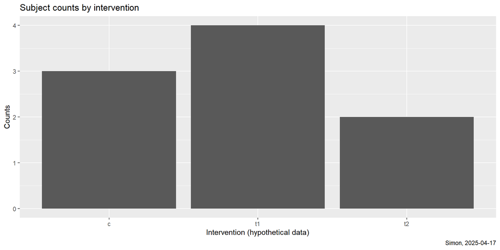

## Barplot of percents

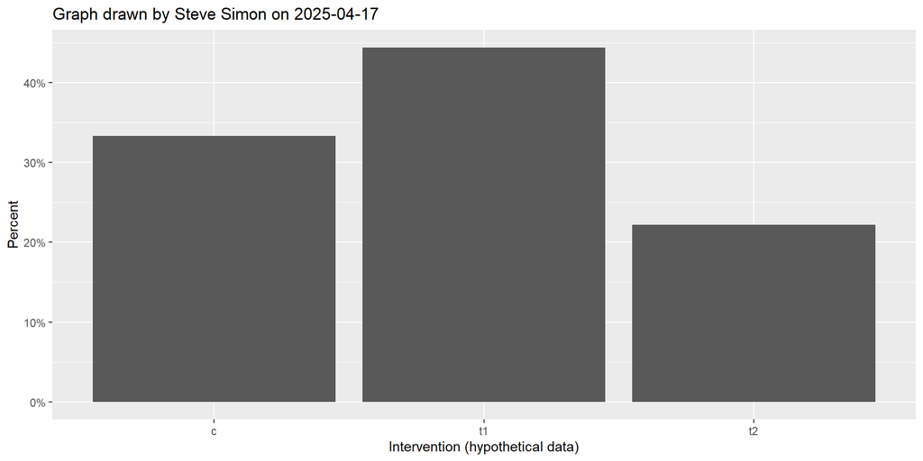

## Barplot with two categorical counts, 1

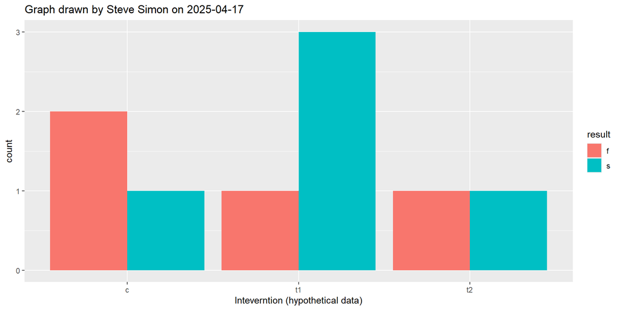

## Barplot with two categorical counts, 2

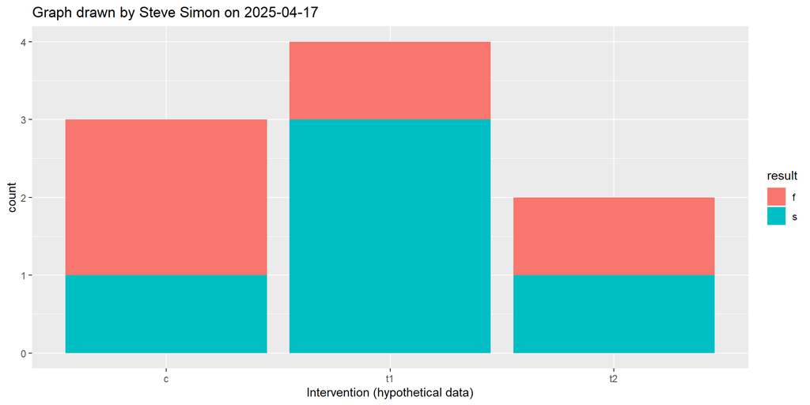

## Barplot with two categorical percentages, 1

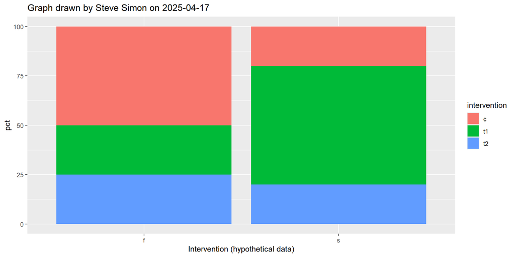

## Barplot with two categorical percentages, 2

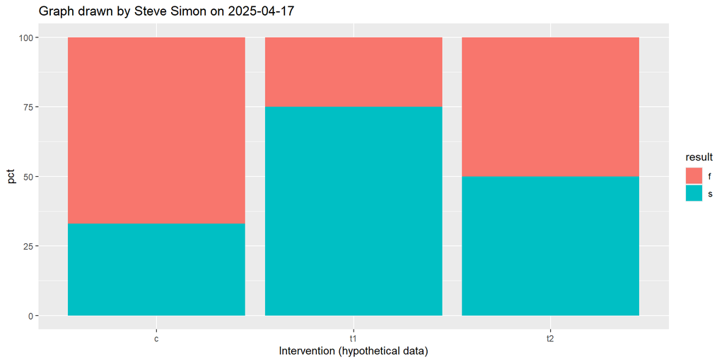

## Barplot with two categorical percentages, 2

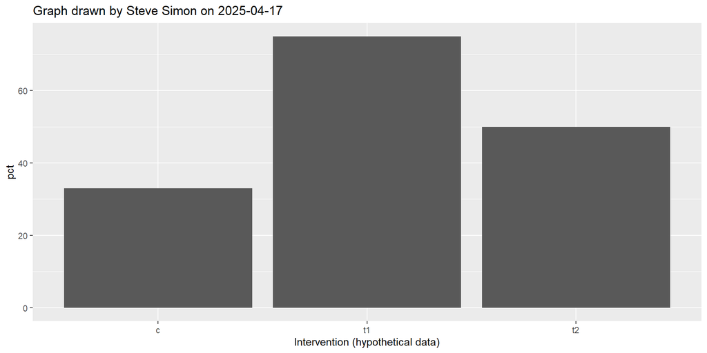

## Break #4

- What you have learned
  - Bar plots
- What’s coming next
  - New categorical variables

## Converting a continuous variable to categorical

```
ti_1 |>
    mutate(child=case_when(
    is.na(age) ~ "Unknown",
    age <=  0  ~ "Invalid",
    age >= 91  ~ "Invalid",
    age <  18  ~ "Yes",
    age >= 18  ~ "No")) -> ti_2
```

## Quality check, 1

[output not shown]

## Combining categories

```
ti_2 |>
    mutate(third_class = case_when(
    is.na(pclass) ~ NA,
    pclass=="1st" ~ 0,
    pclass=="2nd" ~ 0,
    pclass=="3rd" ~ 1)) -> ti_3
```

## Quality check, 2

[output not shown]

## Summary

- What you have learned
  - Review statistics for continuous outcomes
  - Counts, proportions, and percentages
  - Crosstabulations
  - Bar plots
  - New categorical variables